# Koło Naukowe Uczenia Maszynowego ATLAS - Bootcamp 2023

# Spotkanie 1 - Wprowadzenie

## 1. O Kole

[figure not shown]

### 1. Podstawowe informacje dotyczące Koła

- Koło zostało założone w lipcu 2023 r.
- Funkcjonuje przy Katedrze Matematyki Stosowanej Wydziału Matematyki i Informatyki Technicznej
- Opiekunem Koła jest mgr inż. Magdalena Piłat-Rożek
- Zarząd na ten rok akademicki:
- Paweł Woźniak - Prezes
- Kacper Wójtowicz - Wiceprezes
- Patryk Marek - Sekretarz
- Michał Koziński - Skarbnik

### 2. Cele Koła

Celem Koła jest poszerzanie wiedzy studentów przede wszystkim na tematy związane z uczeniem maszynowym oraz sztuczną inteligencją. Chcemy tego dokonać poprzez:

- Organizację corocznych bootcampów - takich jak ten!
- Study Groups - podzielenie członków Koła na grupy, które skupiałyby się bardziej szczegółowo na jakichś tematach, np. Computer Vision, NLP itd.
- Wyjazdy na Hackathony oraz konferencje związane z ML/AI
- Udział w projektach naukowych i dydaktycznych Katedry Matematyki Stosowanej
- Organizację prelekcji

### 3. Dotychczasowe aktywności

- Hackathony
- KNUM x Golem Hackathon 2022
- BEST Hacking League 2023 (3. miejsce w kategorii Artificial Intelligence)
- HackYeah 2023
- Noc inżynierów 2023
- Lubelski Festiwal Nauki 2023
- Data Saturday 2023
- ML in PL Conference 2023 (soon)

### 4. Dołączenie do Koła

Zainteresowanych dołączeniem do Koła prosimy o wypełnienie formularza.

[figure not shown]

## 2. Struktura bootcampu

- Odbędą się 4 spotkania
1. Wprowadzenie
2. Regresja
3. Klasyfikacja
4. Podsumowanie & feedback
- Każde spotkanie ma przygotowaną część teoretyczną oraz praktyczną, zarówno w R jak i Pythonie.
- Po trzecim spotkaniu udostępnimy konkurs, w którym będziecie mogli sprawdzić swoje umiejętności

## 3. Dane

#### Podstawowe pojęcia

[figure not shown]

Poniższe dane pochodzą ze zbioru `penguins` z pakietu `palmerpenguins` w R.  
Korzystając z poniższej tabeli odpowiemy sobie teraz na kilka podstawowych pytań:

1. Czym jest obserwacja?
2. Czym jest cecha?
3. Jakie wyróżniamy typy cech?
4. Czym jest predyktor/zmienna niezależna?
5. Czym jest target/zmienna niezależna?

| species | island | bill_length_mm | bill_depth_mm | flipper_length_mm | body_mass_g | sex | year |
| --- | --- | --- | --- | --- | --- | --- | --- |
| Adelie | Torgersen | 39.1 | 18.7 | 181 | 3750 | male | 2007 |
| Adelie | Torgersen | 39.5 | 17.4 | 186 | 3800 | female | 2007 |
| Adelie | Torgersen | 40.3 | 18.0 | 195 | 3250 | female | 2007 |
| Adelie | Torgersen | NA | NA | NA | NA | NA | 2007 |
| Adelie | Torgersen | 36.7 | 19.3 | 193 | 3450 | female | 2007 |
| Adelie | Torgersen | 39.3 | 20.6 | 190 | 3650 | male | 2007 |

**Odpowiedzi**

1. Obserwacja to pojedynczy wiersz w tabeli.
2. Cecha to pojedyncza kolumna, służy do opisu danej obserwacji, w naszej tabeli jest to np. `body_mass_g` lub `Species`.
3. Cechy, zwane też zmiennymi, dzielimy na:
- Zmienne typu ciągłego - przyjmują dowolne wartości liczbowe z $\mathbb{R}$, np. `bill_depth_mm`.
- Zmienne typu jakościowego - są to nieporównywalne między sobą stany, gdzie jeden nie jest lepszy od drugiego, np. `Species`.
- Zmienne typu porządkowego - są to zmienne typu jakościowego, lecz mają ustalony porządek, w naszym zbiorze nie znajduje się taka zmienna, ale mogłoby to być np. `wykształcenie`, gdzie podstawowe < średnie < wyższe.
4. Predyktorem nazywamy cechę, która wykorzystywana będzie do przewidywania wartości zmiennej wynikowej (targetu/zmiennej niezależnej), w naszej tabelce jest to np. zmienna `body_mass_g`.
5. Inaczej zmienna wynikowa. Cecha, którą będziemy przewidywać, w rzeczywistości jest to wartość nieznana. W powyższym zbiorze może to być `Species`, czyli gatunek pingwina.

#### Podział danych

[figure not shown]

Dane dzielimy na zbiór treningowy i testowy. Zbiór treningowy zazwyczaj stanowi większość wszystkich obserwacji, często jest to 70-90%, zależnie od liczby obserwacji, którymi dysponujemy. Ten pierwszy wykorzystujemy do nauczenia modelu. Wszystkie operacje, np. normalizacja, wykonujemy tylko na zbiorze uczącym.  
Do zbioru testowego wracamy dopiero, gdy mamy gotowy model. Używamy go w celu określenia skuteczności naszego modelu. Dlaczego to ważne?

#### Przeuczenie i niedouczenie

[figure not shown]

W rzeczywistości w zadaniach modelowania możemy mieć do czynienia z trzema sytuacjami.

1. Model jest niedouczony - jest słabo dopasowany zarówno do danych treningowych, jak i testowych. Słabe wyniki predykcji w tym przypadku mogą wynikać z czynników takich jak:
- Zbyt mały zbiór uczący
- Za mało predyktorów
- Dostępne predyktory nie mówią wystarczająco dużo o zmiennej wynikowej.
- Model jest zbyt prosty, nie jest w stanie odwzorować skomplikowanych zależności pomiędzy cechami.
2. Model jest dobrze nauczony - w takiej sytuacji model osiąga dobre, zbliżone wyniki na zbiorze treningowym i testowym.
3. Model jest przeuczony - w tej sytuacji model osiąga zadowalające wyniki na zbiorze treningowym, natomiast ze zbiorem testowym radzi sobie dużo gorzej. Przeuczenie może wynikać z takich rzeczy jak:
- Zbyt mały zbiór uczący
- Model jest zbyt złożony

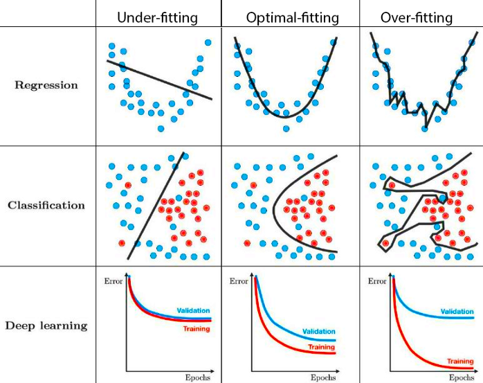

Przykład pochodzi z www.towardsdatascience.com

## 4. Czym jest uczenie maszynowe, czyli jak uczą się modele?

[figure not shown]

Tradycyjne programowanie algorytmów polega na tworzeniu zasad w celu otrzymania wyniku. W uczeniu maszynowym pokazujemy specjalnemu algorytmowi dane, wraz z wynikiem w celu znalezienia reguł, wzorców, pozwalających na otrzymywanie odpowiedzi dla nowych, nieznanych obserwacji.  
W tradycyjnym programowaniu jeśli pojawiłaby się nowa obserwacja, nie wpasowująca się w tworzone reguły, nie będziemy w stanie otrzymać poprawnej odpowiedzi.

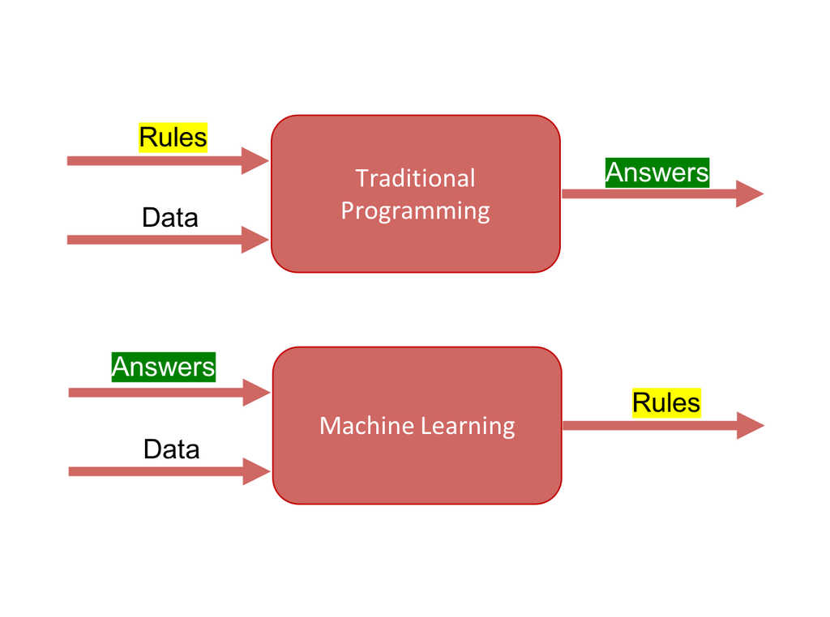

Algorytmy uczenia maszynowego możemy podzielić na nadzorowane (ang. *supervised*) i nienadzorowane (ang. *unsupervised*). W uczeniu nadzorowanym mamy “nauczyciela”, który najczęściej jest zmienną wynikową i mówi algorytmowi jaka jest odpowiedź przy zadanych wartościach cech, co pozwala ustalić mu zależności. Na przykład, jeśli chcemy wykryć, czy dany mail jest spamem, czy nie i dysponujemy zbiorem, który zawiera wiadomości z oznaczeniem, czy były spamem, czy nie, wtedy skorzystamy z algorytmów uczenia nadzorowanego.

W uczeniu nienadzorowanym nie mamy “nauczyciela”, dysponujemy obserwacjami bez zmiennej wynikowej. Z takich algorytmów korzystamy, np. w algorytmach grupujących, gdzie wcześniej nie znamy grup, do których należą obserwacje, czyli nie ma nauczyciela. Algorytmów grupujących używamy, żeby np. stwierdzić, że żywieniowo Polska jest bardziej podobna do Ukrainy, a Hiszpania jest bardziej podobna do Portugalii.

[figure not shown]

#### Regresja i klasyfikacja

Algorytmy uczenia nadzorowanego możemy dalej podzielić na algorytmy regresyjne i klasyfikacyjne. Zadania regresyjne służą przewidywaniu ciągłych wartości, np. ceny mieszkania, miesięcznych wydatków klienta w naszym sklepie itd. Zadania klasyfikacyjne służą przewidywaniu wartości dyskretnych, np. czy klient kupi nasz produkt lub czy wiadomość jest spamem.

#### Funkcja straty

> A way to measure whether the algorithm is doing a good job — This is necessary to determine the distance between the algorithm’s current output and its expected output. The measurement is used as a feedback signal to adjust the way the algorithm works. This adjustment step is what we call learning.

François Chollet, Deep learning with Python (2017), Manning, chapter 1 p.6

Funkcja straty jest funkcją, która oblicza odległość pomiędzy obecną przewidywaną wartością, a oczekiwaną. Funkcja straty ewaluuje to, jak dobrze algorytm modeluje dane. Funkcje straty używane są zarówno dla zadań regresyjnych, jak i klasyfikacyjnych.

##### Mean Square Error Loss

Błąd średniokwadratowy jest prostą i bardzo popularną funkcją straty. Używany jest do zadań regresyjnych. Jest to suma kwadratów różnic pomiędzy przewidywaną, a prawdziwą wartością. Wzór na MSE:
$$MSE = \frac{1}{n}\sum_{i=0}^{n}(y_i-\hat{y}_i)^2,$$
gdzie:
– $n$ - liczba obserwacji
– $y_i$ - i-ta obserwacja
– $\hat{y}_i$ - predykcja dla i-tej obserwacji

Poszukiwanie optymalnej (minimalnej) wartości funkcji straty można sobie wyobrazić jako “kule toczącą się po płaszczyźnie” poszukujęcej globalnego minimum (w naszym przykładzie “dołka który leży najniżej)

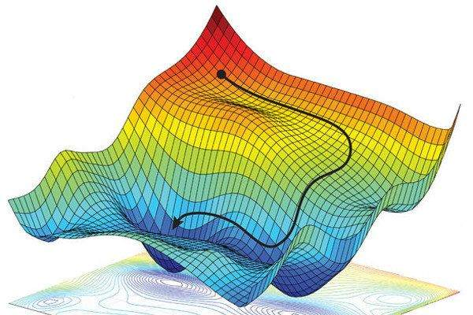

## Z czego będziemy korzystali?

### R

1. Język R - dostępny do pobrania na CRAN ([link](https://cran.rstudio.com/)).
2. IDE - środowisko programistyczne, polecamy Rstudio ([link](https://posit.co/download/rstudio-desktop/)).
3. Rtools - zestaw narzędzi do R (wersja dla Windows: [link](https://cran.r-project.org/bin/windows/Rtools/)).
4. Biblioteki - będziemy instalować na bieżąco, najwżaniejsze będą `tidyverse` i `tidymodels`.

### Python

1. Język Python - polecamy dystrybucję Anaconda ([link](https://www.anaconda.com/download))
2. IDE - głównie Jupyter Notebook (instalowany razem z Anacondą), polecamy też Visual Studio Code i PyCharm.
3. Biblioteki - będziemy instalować na bieżąco, najważniejsze będą: `pandas`, `NumPy`, `Matplotlib` i `scikit-learn`